#Title: Predictive Modeling of Mouse Decision-Making Using Neural Spike Data

#Abstract:

This study leverages neural activity data from visual cortex recordings of mice to predict behavioral outcomes (feedback type) based on spike train patterns and stimulus contrasts. Utilizing data from a subset of experiments by Steinmetz et al. (2019), our analysis specifically investigates the association between neuronal spike activity during visual stimulus presentation and subsequent decision-making behaviors in mice. The project is separated into six parts, which of them are introduction, exploratory analysis, data integration, predictive modeling, prediction performance on the test sets, and discussion. The project uses many methods to analyze the data like plotting, normalization and then selects some models like decision trees and random forests to predict the outcome based on the features of the data.

#Section 1 Introduction

Understanding how neural activity translates into behavioral outcomes is fundamental in neuroscience. In a series of experiments conducted by Steinmetz et al. (2019), mice were presented with visual stimuli of varying contrasts and tasked with decision-making behaviors that resulted in either rewards or penalties. Neural activity in the visual cortex was simultaneously recorded, producing spike trains—temporal sequences of neuron firings.Our project aims to analyze spike train data from 18 sessions involving four different mice—Cori, Forssman, Hench, and Lederberg—to build predictive models capable of classifying the trial outcomes based solely on neural and visual stimulus data. Each trial’s feedback (success or failure) is associated with the contrasts presented (left and right stimuli) and neuronal activity, recorded as spike counts within specified time bins.By applying advanced statistical modeling techniques, including tree-based algorithms, our study seeks to elucidate the relationship between neuronal dynamics and behavioral decision-making. The outcomes of this study will offer insights into neural encoding and decoding processes and potentially inform future research in neural correlates of decision-making.

# Section 2 Exploratory analysis

#2.1 Summarizing Table

```r
# Load required libraries
library(dplyr)
library(knitr)

# Define the folder path containing session files
folder_path <- "C:/Users/29707/OneDrive/Desktop/sessions"

# Initialize a list to store session data
session <- list()

# Loop through all 18 session files and load them
for (i in 1:18) {
  session[[i]] <- readRDS(paste0(folder_path, "/session", i, ".rds"))  # Corrected concatenation
}

# Process each session and extract relevant data
all_sessions <- bind_rows(
  lapply(1:18, function(i) {
    data <- session[[i]]

    # Compute summary statistics
    success_count <- sum(data$feedback_type == 1, na.rm = TRUE)
    failure_count <- sum(data$feedback_type == -1, na.rm = TRUE)
    mean_contrast_left <- mean(data$contrast_left, na.rm = TRUE)
    mean_contrast_right <- mean(data$contrast_right, na.rm = TRUE)

    # Ensure neuron count is derived correctly
    neuron_count <- if (is.list(data$spks) && length(data$spks) > 0) {
      nrow(data$spks[[1]])  # Use the first trial to determine neuron count
    } else {
      NA  # If no spikes available, set to NA
    }

    # Return a **single row per session**
    data.frame(
      session_id = i,  # Assign session number
      Mouse = unique(data$mouse_name),
      Date = unique(data$date_exp),
      neuron_count = neuron_count,
      trial_count = length(data$spks),
      mean_contrast_left = mean_contrast_left,
      mean_contrast_right = mean_contrast_right,
      success_count = success_count,
      failure_count = failure_count,
      success_rate = success_count / (success_count + failure_count),
      mean_spikes = mean(unlist(data$spks), na.rm = TRUE),# Avoid dividing by zero
      Variance_SpikeRate=var(unlist(data$spks), na.rm = TRUE)
    )
  })
)

# Display the cleaned table
kable(all_sessions, digits = 6)
```

| session_id | Mouse | Date | neuron_count | trial_count | mean_contrast_left | mean_contrast_right | success_count | failure_count | success_rate | mean_spikes | Variance_SpikeRate |
| --- | --- | --- | --- | --- | --- | --- | --- | --- | --- | --- | --- |
| 1 | Cori | 2016-12-14 | 734 | 114 | 0.296053 | 0.429825 | 69 | 45 | 0.605263 | 0.038491 | 0.043107 |
| 2 | Cori | 2016-12-17 | 1070 | 251 | 0.317729 | 0.351594 | 159 | 92 | 0.633466 | 0.031641 | 0.034231 |
| 3 | Cori | 2016-12-18 | 619 | 228 | 0.235746 | 0.368421 | 151 | 77 | 0.662281 | 0.055848 | 0.061511 |
| 4 | Forssmann | 2017-11-01 | 1769 | 249 | 0.334337 | 0.322289 | 166 | 83 | 0.666667 | 0.021039 | 0.022927 |
| 5 | Forssmann | 2017-11-02 | 1077 | 254 | 0.338583 | 0.356299 | 168 | 86 | 0.661417 | 0.027896 | 0.030775 |
| 6 | Forssmann | 2017-11-04 | 1169 | 290 | 0.353448 | 0.325000 | 215 | 75 | 0.741379 | 0.016580 | 0.017703 |
| 7 | Forssmann | 2017-11-05 | 584 | 252 | 0.293651 | 0.325397 | 169 | 83 | 0.670635 | 0.035384 | 0.044807 |
| 8 | Hench | 2017-06-15 | 1157 | 250 | 0.442000 | 0.375000 | 161 | 89 | 0.644000 | 0.041389 | 0.045476 |
| 9 | Hench | 2017-06-16 | 788 | 372 | 0.406586 | 0.267473 | 255 | 117 | 0.685484 | 0.039684 | 0.043296 |
| 10 | Hench | 2017-06-17 | 1172 | 447 | 0.384787 | 0.270134 | 277 | 170 | 0.619687 | 0.029688 | 0.033580 |
| 11 | Hench | 2017-06-18 | 857 | 342 | 0.334795 | 0.313596 | 272 | 70 | 0.795322 | 0.031262 | 0.034326 |
| 12 | Lederberg | 2017-12-05 | 698 | 340 | 0.288971 | 0.325000 | 251 | 89 | 0.738235 | 0.041582 | 0.043694 |
| 13 | Lederberg | 2017-12-06 | 983 | 300 | 0.355833 | 0.305000 | 239 | 61 | 0.796667 | 0.061442 | 0.066299 |
| 14 | Lederberg | 2017-12-07 | 756 | 268 | 0.332090 | 0.305970 | 186 | 82 | 0.694030 | 0.025165 | 0.027367 |
| 15 | Lederberg | 2017-12-08 | 743 | 404 | 0.339109 | 0.334777 | 309 | 95 | 0.764851 | 0.036602 | 0.039574 |
| 16 | Lederberg | 2017-12-09 | 474 | 280 | 0.367857 | 0.307143 | 201 | 79 | 0.717857 | 0.026259 | 0.027935 |
| 17 | Lederberg | 2017-12-10 | 565 | 224 | 0.324777 | 0.387277 | 186 | 38 | 0.830357 | 0.029145 | 0.033172 |
| 18 | Lederberg | 2017-12-11 | 1090 | 216 | 0.319444 | 0.303241 | 174 | 42 | 0.805556 | 0.027411 | 0.030473 |

There are 18 sessions in total and each of them contains five variables for every trial. They are the type of feedback(1 for success and -1 for failure), contrast of the left stimulus, contrast of the right stimulus, centers of the time bins for spikes, numbers of spikes of neurons in the visual cortex and area of the brain where each neuron lives. The project builds a table to combine all the data together clearly. The table groups the data as session and summarizes some important data. It contains the mouse name, the number of neuron, the number of trials, the mean of the contrast for right and left stimuli, the success and failure count success rate and the mean spikes in each session. Since there are so many trials for spikes in each session so that calculating the mean spikes make it easier to analyze the change of the spikes in each session. The success rate, success and failure count, and the mean of contrast stimuli are to investigate the relationship between change of feedback and the contrast stimuli in each session. Obviously, there the range of the number of neuron is from 474 to 1769 and the range of the number of triasl is from 114 to 447, which indicate the data is large so that the trained predictive model is more accurate and the result is more convincing. What’s more, all of the success rate surpass the 0.5, which indicates the possibility of success rate is high and the mouse is making correct decisions in the visual task more frequently.

#2.2 Feedback Types

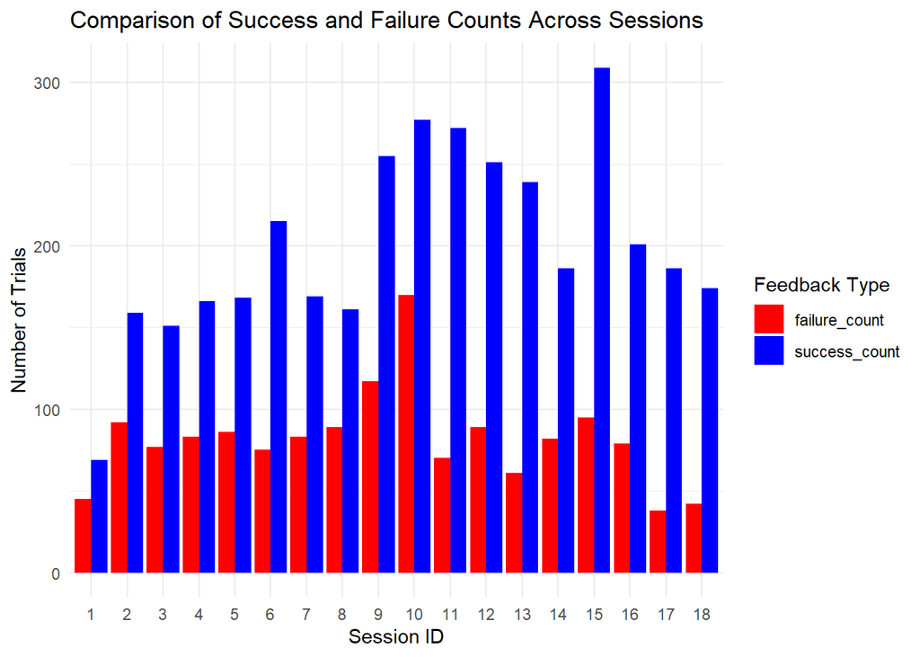

```r
library(ggplot2)
library(dplyr)
library(tidyr)

all_sessions_long <- all_sessions %>%
  pivot_longer(cols = c(success_count, failure_count),
               names_to = "Feedback_Type",
               values_to = "Count")

ggplot(all_sessions_long, aes(x = as.factor(session_id), y = Count, fill = Feedback_Type)) +
  geom_bar(stat = "identity", position = "dodge") +  # Dodge for side-by-side bars
  labs(title = "Comparison of Success and Failure Counts Across Sessions",
       x = "Session ID",
       y = "Number of Trials",
       fill = "Feedback Type") +
  theme_minimal() +
  scale_fill_manual(values = c("success_count" = "blue", "failure_count" = "red"))
```

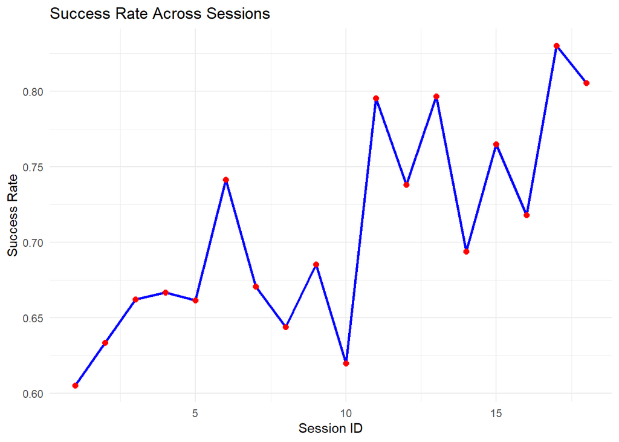

```r
ggplot(all_sessions_long, aes(x = session_id, y = success_rate)) +
  geom_line(color = "blue", size = 1) +  # Creates a smooth curve
  geom_point(color = "red", size = 2) +  # Adds points at each session
  labs(
    title = "Success Rate Across Sessions",
    x = "Session ID",
    y = "Success Rate"
  ) +
  theme_minimal()
```

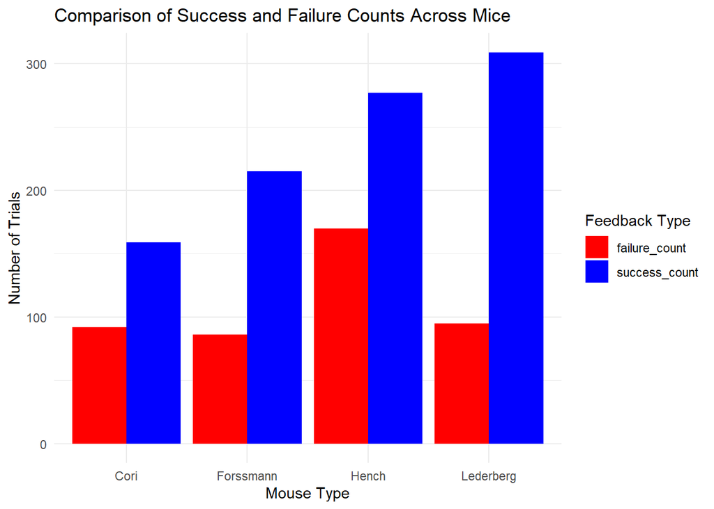

```r
ggplot(all_sessions_long, aes(x = as.factor(Mouse), y = Count, fill = Feedback_Type)) +
  geom_bar(stat = "identity", position = "dodge") +  # Dodge for side-by-side bars
  labs(title = "Comparison of Success and Failure Counts Across Mice",
       x = "Mouse Type",
       y = "Number of Trials",
       fill = "Feedback Type") +
  theme_minimal() +
  scale_fill_manual(values = c("success_count" = "blue", "failure_count" = "red"))
```

Obviously, the number of trials fluctuates across sessions, with the highest number occurring in sessions 10 and 15. The success rate starts around 60% in the early sessions and shows a general upward trend and there are fluctuations, but the success rate exceeds 80% in later sessions, suggesting learning and adaptation in the plot of sauccess rate across sessions.Different mice exhibit varying performance levels so that the mouse type does not show the obvious relativity with the feedback type.

#2.3 stimulus conditions

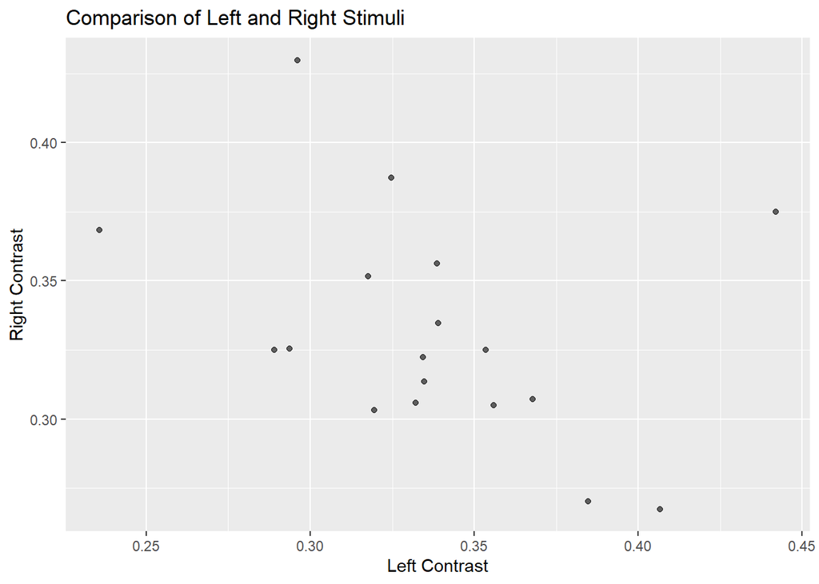

```r
library(tidyr)
library(ggplot2)


  all_sessions_sti <- all_sessions %>%
     select(Mouse,session_id, mean_contrast_left, mean_contrast_right, success_count, failure_count) %>%
    pivot_longer(cols = c(mean_contrast_left, mean_contrast_right),
                 names_to = "Contrast_Type",
                 values_to = "Contrast_Value") %>%
    pivot_longer(cols = c(success_count, failure_count),
                 names_to = "Feedback_Type",
                 values_to = "Count")

  ggplot(all_sessions, aes(x = mean_contrast_left, y = mean_contrast_right)) +
  geom_point(alpha = 0.6) +
  labs(title = "Comparison of Left and Right Stimuli",
       x = "Left Contrast",
       y = "Right Contrast")
```

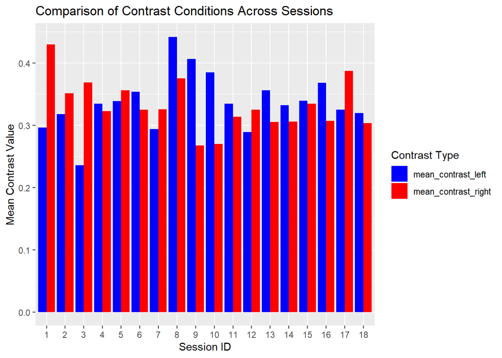

```r
ggplot(all_sessions_sti, aes(x = as.factor(session_id), y = Contrast_Value, fill = Contrast_Type)) +
  geom_bar(stat = "identity", position = "dodge") +
  labs(title = "Comparison of Contrast Conditions Across Sessions",
       x = "Session ID",
       y = "Mean Contrast Value",
       fill = "Contrast Type") +
  scale_fill_manual(values = c("mean_contrast_left" = "blue", "mean_contrast_right" = "red"))
```

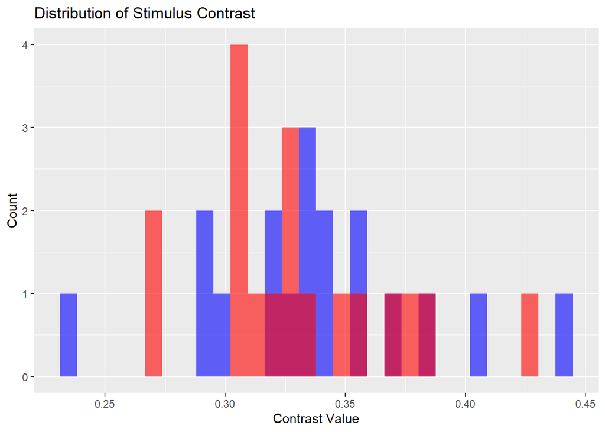

```r
  ggplot(all_sessions) +
  geom_histogram(aes(x =  mean_contrast_left), bins = 30, fill = "blue", alpha = 0.6) +
  geom_histogram(aes(x =  mean_contrast_right), bins = 30, fill = "red", alpha = 0.6) +
  labs(title = "Distribution of Stimulus Contrast",
       x = "Contrast Value",
       y = "Count")
```

[figure not shown]

```r
ggplot(all_sessions_sti, aes(x = as.factor(Feedback_Type), y = Contrast_Type, fill = as.factor(Feedback_Type))) +
  geom_violin(trim = FALSE, alpha = 0.5) +
  geom_boxplot(width = 0.2, fill = "white", outlier.shape = NA) +  # Adds a box plot inside violin plot
  labs(title = "Stimuli Contrast Differences Between Success and Failure Trials",
       x = "Success and Failure Trials",
       y = "Contrast Type")
```

[figure not shown]

```r
ggplot(all_sessions_sti, aes(x =  Contrast_Type, fill = as.factor(Feedback_Type))) +
  geom_density(alpha = 3) +  # Transparent density curves
  labs(title = "Density of Stimulus Contrast for Success vs. Failure",
       x = "Contrast Type",
       y = "Density") +
  scale_fill_manual(values = c("1" = "purple", "-1" = "brown"))
```

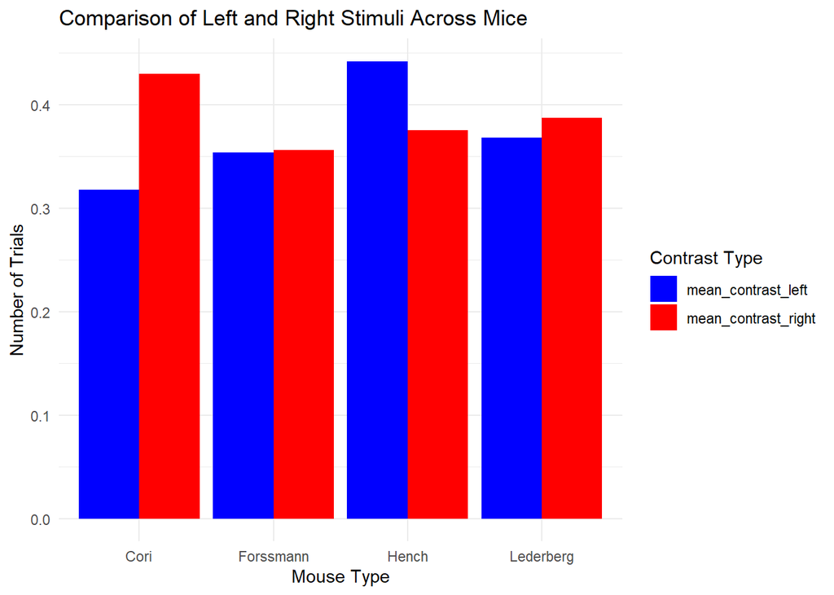

```r
ggplot(all_sessions_sti, aes(x = as.factor(Mouse), y = Contrast_Value, fill = Contrast_Type)) +
  geom_bar(stat = "identity", position = "dodge") +  # Dodge for side-by-side bars
  labs(title = "Comparison of Left and Right Stimuli Across Mice",
       x = "Mouse Type",
       y = "Number of Trials",
       fill = "Contrast Type") +
  theme_minimal() +
  scale_fill_manual(values = c("mean_contrast_left" = "blue", "mean_contrast_right" = "red"))
```

#2.4 Neuron

[figure not shown]

```r
# Plot neurons per session
library(ggplot2)
ggplot(all_sessions, aes(x = session_id, y = mean_spikes
)) +
  geom_bar(stat = "identity", fill = "blue") +
  labs(title = "Number of Neurons Per Session", x = "Session", y = "Number of Neurons")
```

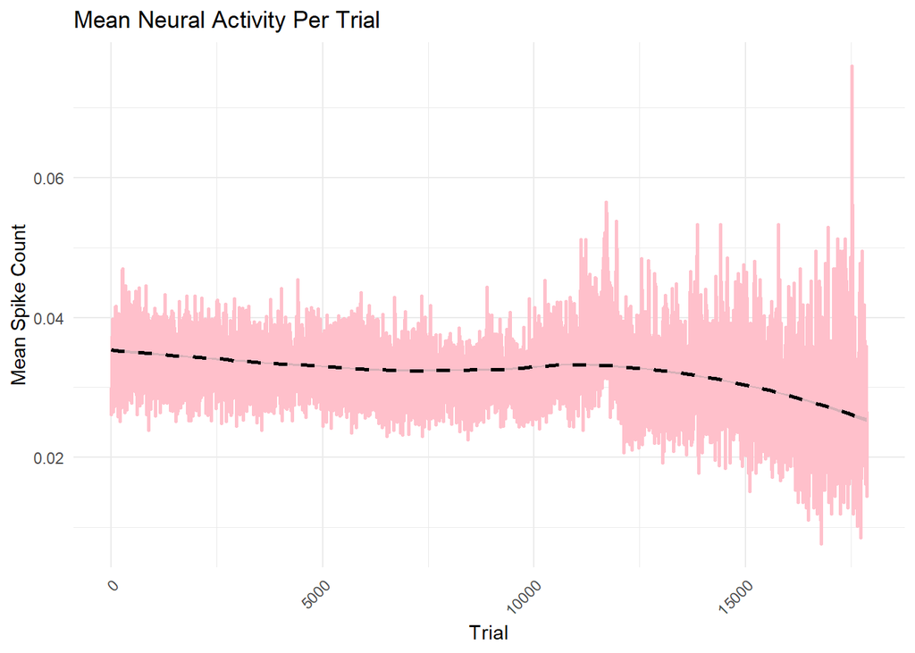

```r
# Define the folder path containing session files
folder_path <- "C:/Users/29707/OneDrive/Desktop/sessions"

# Initialize a list to store session data
session <- list()

# Loop through all 18 session files and load them
for (i in 1:18) {
  session[[i]] <- readRDS(paste0(folder_path, "/session", i, ".rds"))  # Corrected concatenation
}

# Process each session and extract relevant data
all_sessions_spks<- bind_rows(
  lapply(1:18, function(i) {
    data <- session[[i]]

    # Return a **single row per session**
    data.frame(
      mean_spikes = data$spks

    )
  })
)



mean_spikes_per_trial <- sapply(all_sessions_spks, function(spk) {
    if (is.null(spk)) return(NA) # Avoid errors if missing data
    mean(unlist(spk), na.rm = TRUE)
})


if (length(mean_spikes_per_trial) > 0) {
    mean_spikes_df <- data.frame(
        Trial = seq_along(mean_spikes_per_trial),
        Mean_Spikes = mean_spikes_per_trial
    )
} else {
    print("Error: mean_spikes_per_trial is empty")
}


ggplot(mean_spikes_df, aes(x = Trial, y = Mean_Spikes)) +
    geom_line(color = "pink", size = 1) +  # Line to show trend
    geom_smooth(method = "loess", color = "black", linetype = "dashed", size = 1) +  # Smoothed trend line
    labs(title = "Mean Neural Activity Per Trial",
         x = "Trial",
         y = "Mean Spike Count") +
    theme_minimal() +
    theme(axis.text.x = element_text(angle = 45, hjust = 1))  # Improve x-axis readability
```

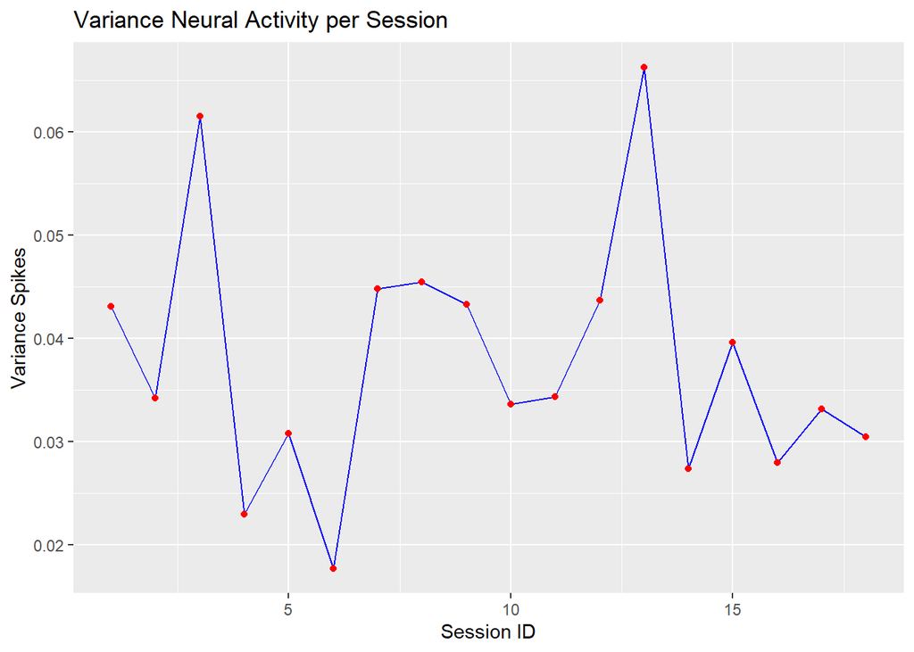

```r
ggplot(all_sessions, aes(x = session_id, y = Variance_SpikeRate)) +
  geom_line(color = "blue") +
  geom_point(color = "red") +
  labs(title = "Variance Neural Activity per Session",
       x = "Session ID",
       y = "Variance Spikes")
```

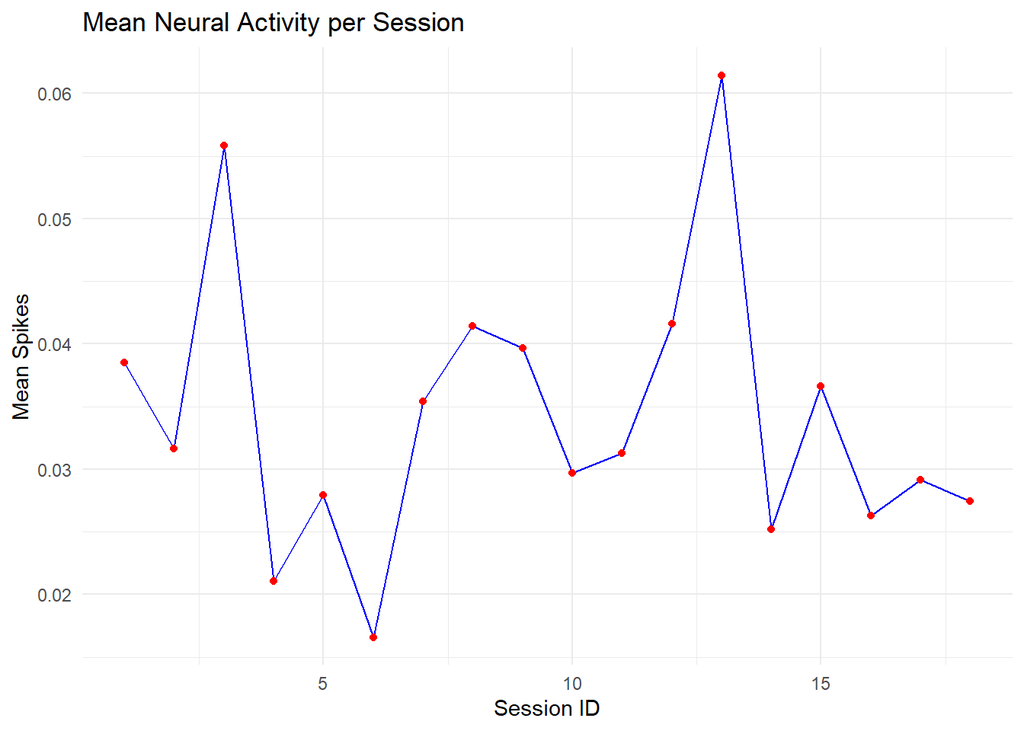

```r
ggplot(all_sessions, aes(x = session_id, y = mean_spikes)) +
  geom_line(color = "blue") +
  geom_point(color = "red") +
  labs(title = "Mean Neural Activity per Session",
       x = "Session ID",
       y = "Mean Spikes") +
  theme_minimal()
```

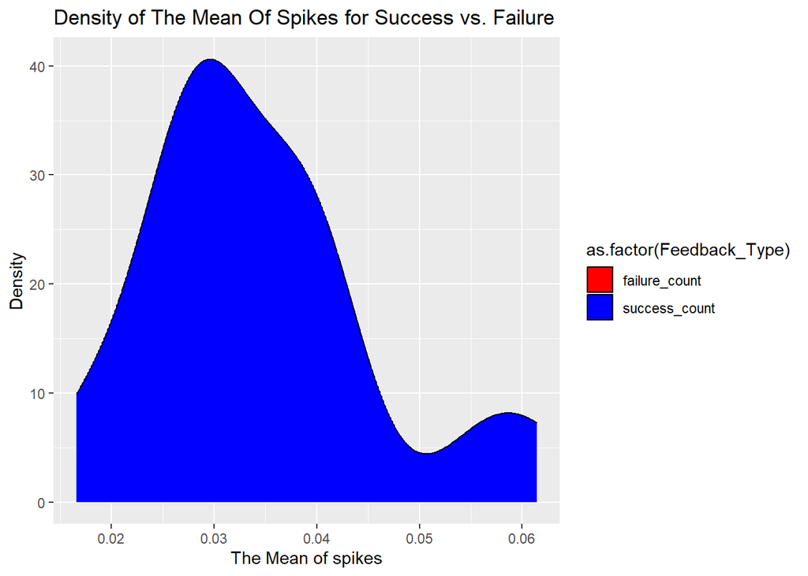

```r
 all_sessions_sti <- all_sessions %>%
    select(Mouse, session_id,mean_spikes,mean_contrast_left, mean_contrast_right, success_count, failure_count) %>%
    pivot_longer(cols = c(success_count, failure_count),
                 names_to = "Feedback_Type",
                 values_to = "Count")


ggplot(all_sessions_sti, aes(x =  mean_spikes, fill = as.factor(Feedback_Type))) +
  geom_density(alpha = 3) +  # Transparent density curves
  labs(title = "Density of The Mean Of Spikes for Success vs. Failure",
       x = "The Mean of spikes",
       y = "Density") +
  scale_fill_manual(values = c("success_count" = "blue", "failure_count" = "red"))
```

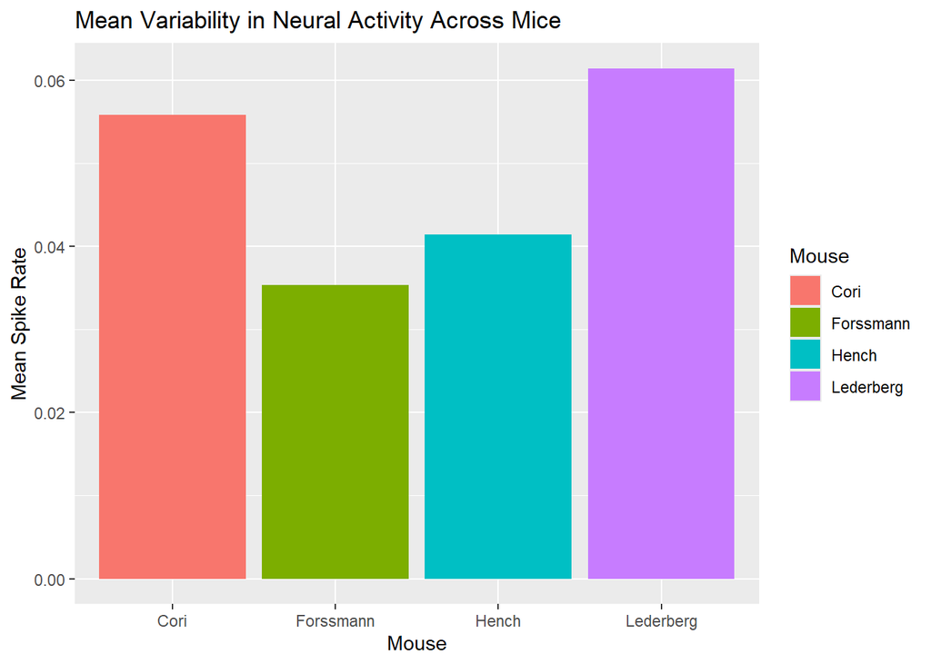

```r
ggplot(all_sessions, aes(x = Mouse, y = mean_spikes, fill = Mouse)) +
  geom_bar(stat = "identity", position = "dodge") +  # Dodge for side-by-side bars +
  labs(title = "Mean Variability in Neural Activity Across Mice",
       x = "Mouse",
       y = "Mean Spike Rate")
```

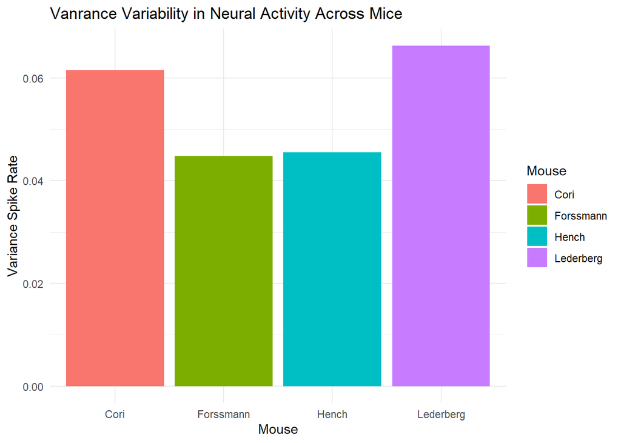

```r
ggplot(all_sessions, aes(x = Mouse, y = Variance_SpikeRate, fill = Mouse)) +
  geom_bar(stat = "identity", position = "dodge") +  # Dodge for side-by-side bars +
  labs(title = "Vanrance Variability in Neural Activity Across Mice",
       x = "Mouse",
       y = "Variance Spike Rate") +
  theme_minimal()
```